# DSSS2022 Machine Learning in R: Task List 03

Goran S. Milovanovic, DataKolektiv

[figure not shown]

# Probability Functions in R

```r
library(tidyverse)
```

Time for serious things: probability functions in R. We will play with the [Binomial Distribution](https://en.wikipedia.org/wiki/Binomial_distribution) today, and review a very important concept in Estimation Theory: the Likelihood Function.

### Binomial probability: tossing a coin

Let’s call a coin that lands heads and tails 50% of the time *a fair coin*. Toss a fair coin ten times and write down the outcomes as (H)ead or (T)ail:

```r
tosses <- c('H', 'H', 'T', 'T', 'H', 'T', 'T', 'H', 'T', 'T')
table(tosses)
```

```
tosses
H T
4 6
```

What is the probability of observing H - P(H) - and the probability of observing T - P(T) in this statistical experiment?

```r
table(tosses)/length(tosses)
```

```
tosses
  H   T
0.4 0.6
```

Now, the `sample()` function:

```r
tosses <- sample(c('H', 'T'), size = 10, replace = TRUE, prob = c(.5, .5))
table(tosses)
```

```
tosses
H T
4 6
```

**TO DO.** Open the documentation, or Google, and learn about the following R functions: `sample()`.

**TO DO.** Open the documentation, or Google, and learn about the following R functions: `t()` and `table()`.

```r
tosses <- lapply(1:10000, function(x) {
  results <- table(
    sample(c('H', 'T'), size = 100, replace = TRUE, prob = c(.5, .5))
  )
  results <- t(as.matrix(results))
  results <- as.data.frame(results)
  return(results)
})
tosses <- Reduce(rbind, tosses)
head(tosses, 10)
```

|  | H | T |
| --- | --- | --- |
| 1 | 47 | 53 |
| 2 | 43 | 57 |
| 3 | 57 | 43 |
| 4 | 48 | 52 |
| 5 | 49 | 51 |
| 6 | 51 | 49 |
| 7 | 46 | 54 |
| 8 | 49 | 51 |
| 9 | 54 | 46 |
| 10 | 55 | 45 |

Let’s count how many times did we observe a particular number of Heads and visualize with ggplot2.

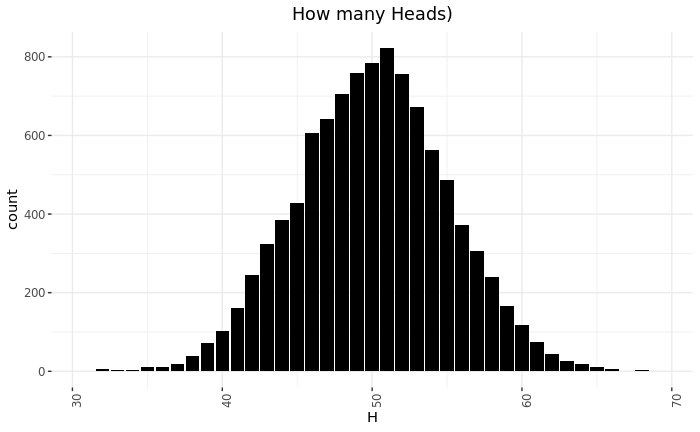

```r
ggplot(data = tosses,
       aes(x = H)) +
  geom_histogram(bins = 50, stat = "count", fill = "black") +
  ggtitle("How many Heads)") +
  theme_bw() +
  theme(panel.border = element_blank()) +
  theme(axis.text.x = element_text(angle = (90))) +
  theme(plot.title = element_text(hjust = .5))
```

And what if the coin was not fair and had a probability of landing Heads of .7?

```r
tosses <- lapply(1:10000, function(x) {
  results <- table(
    sample(c('H', 'T'), size = 100, replace = TRUE, prob = c(.7, .3))
  )
  results <- t(as.matrix(results))
  results <- as.data.frame(results)
  return(results)
})
tosses <- Reduce(rbind, tosses)
head(tosses, 10)
```

|  | H | T |
| --- | --- | --- |
| 1 | 70 | 30 |
| 2 | 68 | 32 |
| 3 | 70 | 30 |
| 4 | 73 | 27 |
| 5 | 69 | 31 |
| 6 | 74 | 26 |
| 7 | 74 | 26 |
| 8 | 78 | 22 |
| 9 | 71 | 29 |
| 10 | 66 | 34 |

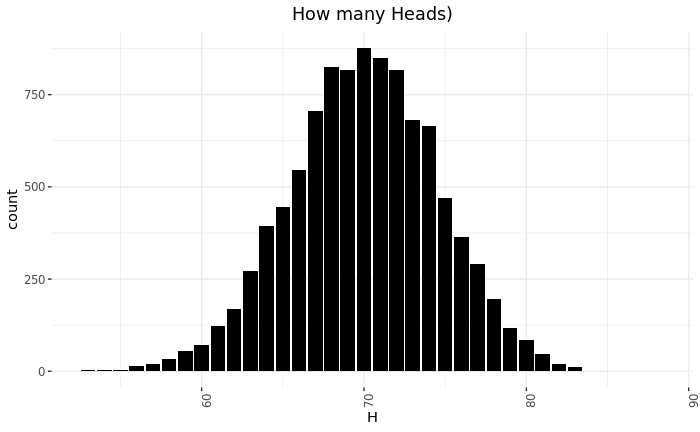

```r
ggplot(data = tosses,
       aes(x = H)) +
  geom_histogram(bins = 50, stat = "count", fill = "black") +
  ggtitle("How many Heads)") +
  theme_bw() +
  theme(panel.border = element_blank()) +
  theme(axis.text.x = element_text(angle = (90))) +
  theme(plot.title = element_text(hjust = .5))
```

The probability of obtaining $k$ successes (conventionally: Heads) with probability $p$ from $n$ trials in a statistical experiment with two possible outcomes {H, T} is given by:

$${P(X=k;n,k)} = {{n}\choose{k}}p^{k}(1-p)^{n-k}$$
where

$${{n}\choose{k}} = \frac{n!}{k!(n-k)!}$$

is the binomial coefficient.

This probability function is called the Binomial Distribution. This is its official R documentation: [Binomial Distribution in R](https://stat.ethz.ch/R-manual/R-devel/library/stats/html/Binomial.html).

### Probability in R: density, cumulative, random numbers, and quantile functions

The Binomial density function is obtained from `dbinom()`:

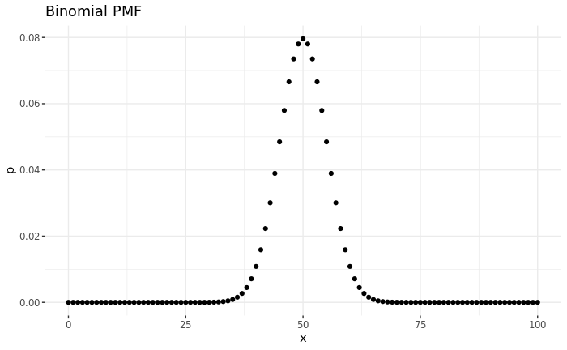

```r
d <- seq(0, 100, by = 1)
y <- dbinom(x = d, size = 100, prob = .5)
data.frame(x = d,
           p = y) %>%
  ggplot(aes(x = x, y = p)) +
  geom_point() +
  ggtitle('Binomial PMF') +
  theme_bw() +
  theme(panel.border = element_blank())
```

The density function (for discrete probability functions like Binomial) answers the following question: what is the probability that we observe `x` successes (“Heads”) in `size = 100` trials (tosses) if the probability of landing a success (a “Head”) is `prob = .5`. In continuous probability functions (like the Normal Distribution) density tells a different story.

The cumulative function is:

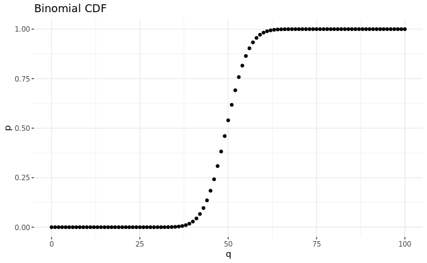

```r
d <- seq(0, 100, by = 1)
y <- pbinom(q = d, size = 100, prob = .5)
data.frame(q = d,
           p = y) %>%
  ggplot(aes(x = q, y = p)) +
  ggtitle('Binomial CDF') +
  geom_point() +
  theme_bw() +
  theme(panel.border = element_blank())
```

The cumulative function (or C.D.F.: the Cumulative Distribution Function) answers the following question: what is the probability that we observe a number of successes that is less or equal to `q` successes (“Heads”) in `size = 100` trials (tosses) if the probability of landing a success (a “Head”) is `prob = 0.5`.

This is how we obtain Binomial random numbers:

```r
y <- rbinom(n = 100, size = 1, prob = .5)
print(y)
```

```
  [1] 0 1 0 0 1 0 0 1 0 0 1 1 1 0 1 1 0 1 1 1 0 0 0 0 0 1 0 1 0 1 0 1 1 1 0 0 1 0 1 1 1 1 1 0 0 1 1 1
 [49] 0 1 0 0 0 0 0 0 0 0 1 0 0 1 0 1 1 0 0 1 1 1 1 1 1 1 0 0 0 0 1 0 1 0 1 1 0 1 0 0 0 0 0 1 0 0 0 1
 [97] 1 1 0 1
```

We have used `rbinom()` to produce `n = 100` random coin tosses, on each occasion tossing a coin only once (`size = 1`) and with a probability of obtaining Heads of `prob = .5`.

Here goes an array of one hundred statistical experiments in which we always toss a coin five times with `prob = .5` to obtain Heads:

```r
y <- rbinom(n = 100, size = 5, prob = .5)
print(y)
```

```
  [1] 3 1 2 3 2 2 3 2 2 2 3 4 2 2 3 4 2 4 2 2 0 1 4 2 4 3 3 1 3 2 3 2 2 3 0 2 5 3 2 4 2 3 2 3 3 3 4 4
 [49] 1 2 3 2 3 3 0 1 2 1 3 2 3 5 2 3 3 2 1 3 2 2 4 3 1 3 2 2 1 3 2 2 3 1 3 1 2 4 2 2 5 3 3 1 0 2 3 3
 [97] 4 3 2 1
```

Finally, the quantile function.

```r
qbinom(.5, size = 10, prob = .5)
```

```
[1] 5
```

It takes the probability value and gives a number whose cumulative value matches the probability value, so we have asked: in a statistical experiment where we toss a coin `size = 10` times, with probability of obtaining Heads `prob = .5`, how many results are found under `.5` of the results? It is an inverse of the cumulative function:

```r
qbinom(.75, size = 10, prob = .5)
```

```
[1] 6
```

```r
qbinom(.5, size = 10, prob = .75)
```

```
[1] 8
```

**NOTE.** In R, you will always find four probability function for any given statistical distribution. For example, we have `dbinom()` for density, `pbinom()` for cumulative function, `qbinom()` for inverse cumulative function, and `rbinom()` for Binomial random numbers; similarly, for the Poisson distribution we have `dpois()`, `ppois()`, `qpois()`, and `rpois()`.

### Binomial Likelihood

Imagine we toss a fair coin with $p_H = .5$ twice and observe two Heads.The probability of observing two heads with $p_H = .5$ is:

$$P(HH|p_H = .5) = .5 * .5 = .5^{2} = .25$$

Now take a look at the following function: $P(HH|p_H)$. Imagine that the data, the results of our observations - that we have seen two heads in a row - are *fixed*. Than $P(HH|p_H)$ is *a function of the parameter* $p_H$. Imagine that we start changing the value of $p_H$ while keeping the data fixed and with every change in parameter we compute the value of $P(HH|p_H)$ again and again. For example, what is the value of $P(HH|p_H)$ if $p_H = .3$?

$$P(HH|p_H = .3) = .3 * .3 = .3^{2} = .09$$

And what if $p_H = .9$?

$$P(HH|p_H = .9) = .9 * .9 = .9^{2} = .81$$

We have observed two heads; in the universe of our small statistical experiment we have actually observed *all heads*, right? So, as we increase the value of $p_H$, the value of $P(HH|p_H)$ tends to increase: it was `.09` when $p_H = .3$, then `.25` for $p_H = .5$, and finally `.81` for $p_H = .9$. Even if we already know that the coin is fair - hence $p_H = .5$ - the *observed data inform us* that it is more *likely* to be higher.

$P(HH|p_H)$, also written as $\mathcal{L}(p_H|HH)$, reads: the **likelihood** of the parameter value $p_H$ *given* the data $HH$. We can plot the whole **Likelihood function** for this experiment easily:

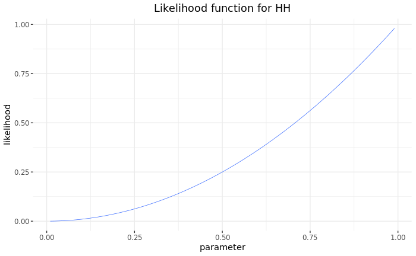

```r
likelihood <- data.frame(parameter = seq(.01, .99, by = .01))
likelihood$likelihood <- likelihood$parameter^2

ggplot(likelihood,
       aes(x = parameter,
           y = likelihood)) +
  geom_smooth(size = .25, se = F) +
  ggtitle("Likelihood function for HH") +
  theme_bw() +
  theme(panel.border = element_blank()) +
  theme(plot.title = element_text(hjust = .5))
```

What if we have observed $HHTTH$ in five tosses?

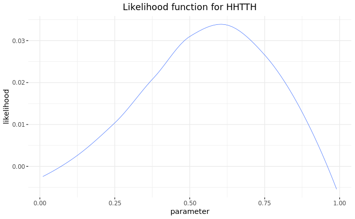

```r
likelihood <- data.frame(parameter = seq(.01, .99, by = .01))

likelihood$likelihood <-
  likelihood$parameter^2 * (1-likelihood$parameter)^2 * likelihood$parameter

ggplot(likelihood,
       aes(x = parameter,
           y = likelihood)) +
  geom_smooth(size = .25, se = F) +
  ggtitle("Likelihood function for HHTTH") +
  theme_bw() +
  theme(panel.border = element_blank()) +
  theme(plot.title = element_text(hjust = .5))
```

How did we get to it? Look, if the data are $HHTTH$, then the Likelihood function for $p_H = .2$ must be:

$$P(HHTTH|p_H = .2) = .2 * .2 * (1-.2) * (1-.2) * .2 = .2^{2} * (1-.2)^{2} * .2 = .00512$$

Let’s check in R:

```r
.2^2*(1-.2)^2*.2
```

```
[1] 0.00512
```

And now we just need to compute the Likelihood function across the whole domain of $p_H$. As simple as that!

[figure not shown]

**Data Science Summer School 2022**  
**Machine Learning in R**  
DataKolektiv, Belgrade, June 2022.